# LASI 2018: Educational measurement and the challenges of inferring learning, R code

#### 2.3 EXPLORE THE DATASET

There are many ways to explore a dataset in R, both via summary statistics and plots. For example:

```r
str(myData)  #lists attributes, their data type and values from the first 10 rows
```

```
## 'data.frame':    491 obs. of  14 variables:
##  $ O1: int  7 7 3 3 7 7 7 7 7 7 ...
##  $ O2: int  6 5 4 3 7 4 7 5 6 4 ...
##  $ O3: int  6 7 4 7 7 7 7 6 7 4 ...
##  $ O4: int  2 6 3 3 7 7 7 6 7 2 ...
##  $ O5: int  7 7 2 2 7 7 7 7 7 7 ...
##  $ C1: int  2 5 3 1 6 5 1 5 5 3 ...
##  $ C2: int  2 6 3 1 1 6 3 6 5 4 ...
##  $ C3: int  2 3 3 2 6 6 1 6 5 4 ...
##  $ C4: int  4 5 3 2 4 5 1 5 5 4 ...
##  $ A1: int  3 1 2 4 1 1 1 3 1 2 ...
##  $ A2: int  3 1 2 3 2 1 3 2 2 2 ...
##  $ A3: int  3 5 4 2 4 4 1 3 4 3 ...
##  $ A4: int  1 1 2 3 1 1 4 1 1 2 ...
##  $ A5: int  4 5 4 2 5 4 1 3 4 3 ...
```

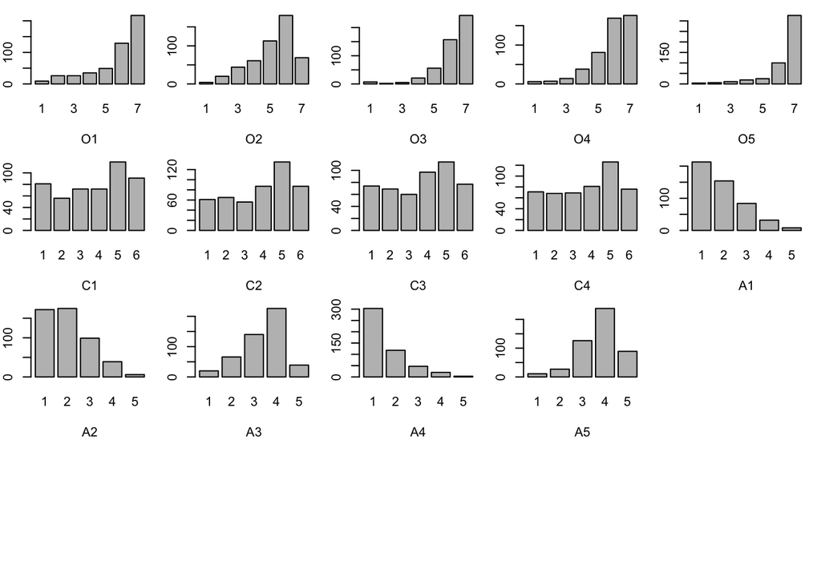

```r
#Visual inspection: A grid of bar plots for all items:
op<-par()   #store default plot parameters (to reset later)
par(mfrow=c(4,5), mar=c(4,2,1,1))           #adjust mfrow for grid size: (rows,colums); mar=margins(b,l,t,r)
for(i in 1:ncol(myData)){
count<-table(myData[,i])
barplot(count, xlab=names(myData)[i])
}
par(op)   #reset to default plot parameters
```

```r
describe(myData) #gives summary statsitics for the dataset
```

```
##    vars   n mean   sd median trimmed  mad min max range  skew kurtosis
## O1    1 491 5.74 1.60      6    6.03 1.48   1   7     6 -1.31     0.76
## O2    2 491 5.19 1.37      6    5.31 1.48   1   7     6 -0.79     0.04
## O3    3 491 6.18 1.12      6    6.39 1.48   1   7     6 -2.08     5.71
## O4    4 491 5.84 1.26      6    6.04 1.48   1   7     6 -1.40     2.17
## O5    5 491 6.38 1.15      7    6.66 0.00   1   7     6 -2.39     5.91
## C1    6 491 3.74 1.74      4    3.80 1.48   1   6     5 -0.28    -1.25
## C2    7 491 3.88 1.65      4    3.97 1.48   1   6     5 -0.40    -1.09
## C3    8 491 3.69 1.68      4    3.74 1.48   1   6     5 -0.25    -1.20
## C4    9 491 3.71 1.67      4    3.77 1.48   1   6     5 -0.27    -1.21
## A1   10 491 1.92 1.00      2    1.77 1.48   1   5     4  0.94     0.20
## A2   11 491 2.05 0.99      2    1.93 1.48   1   5     4  0.70    -0.21
## A3   12 491 3.40 0.96      4    3.46 1.48   1   5     4 -0.61    -0.06
## A4   13 491 1.58 0.87      1    1.41 0.00   1   5     4  1.52     1.75
## A5   14 491 3.75 0.89      4    3.81 1.48   1   5     4 -0.70     0.65
##      se
## O1 0.07
## O2 0.06
## O3 0.05
## O4 0.06
## O5 0.05
## C1 0.08
## C2 0.07
## C3 0.08
## C4 0.08
## A1 0.05
## A2 0.04
## A3 0.04
## A4 0.04
## A5 0.04
```

```r
#Check for missing: is.na(x) returns TRUE of x is missing (not available). The answer should be 0.
#For more information on working with missing values see: https://www.statmethods.net/input/missingdata.html
sum(is.na(myData))
```

```
## [1] 0
```

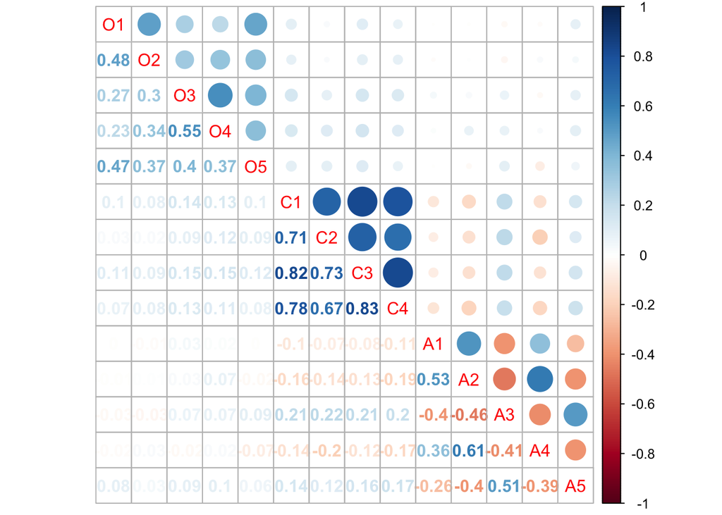

```r
#A correlation plot. (For more ways to visualise correlations see: https://cran.r-project.org/web/packages/corrplot/vignettes/corrplot-intro.html))
correlations<-cor(myData)
#corrplot(correlations, type="lower")   #L.H.S of diagonal only.
corrplot.mixed(correlations)
```

```r
#Note: the correlation plot shows A1, A2 and A4 are reverse scored. This can be 'fixed' as follows:
reverseCodes <- c(1,1,1,1,1,1,1,1,1,-1,-1,1,-1,1)  #Create a vector with -1 indicating items to be reversed
Big5DataR<-as.data.frame(reverse.code(reverseCodes, Big5Data)) #Reversed based on vector above (needed later)
```

##### Exercise:

Set myData to mathsData and run some of the commands above again (myData<-mathsData).

## Section 3: Psychometric measurements

This section will use Big5Data to determine the number of well defined constructs in the dataset.  
FYI: There is a nice introduction to factor analysis at: http://data.library.virginia.edu/getting-started-with-factor-analysis/

#### 3a.1: Exploratory factor analysis

```r
myData <- Big5Data

### Default rotation is orthogonal (rotation="varimax" => independent factors). For oblique set rotation="promax".

fit <- factanal(myData, 3, rotation="varimax")  #This is Base R. 'fa' in Library 'psych' has more options.
print(fit, digits=2, cutoff=.3)
```

```
##
## Call:
## factanal(x = myData, factors = 3, rotation = "varimax")
##
## Uniquenesses:
##   O1   O2   O3   O4   O5   C1   C2   C3   C4   A1   A2   A3   A4   A5
## 0.66 0.65 0.60 0.62 0.56 0.21 0.39 0.13 0.22 0.65 0.32 0.61 0.49 0.69
##
## Loadings:
##    Factor1 Factor2 Factor3
## O1                  0.58
## O2                  0.59
## O3                  0.63
## O4                  0.61
## O5                  0.66
## C1  0.87
## C2  0.77
## C3  0.92
## C4  0.87
## A1          0.59
## A2          0.82
## A3         -0.61
## A4          0.71
## A5         -0.54
##
##                Factor1 Factor2 Factor3
## SS loadings       3.02    2.24    1.93
## Proportion Var    0.22    0.16    0.14
## Cumulative Var    0.22    0.38    0.51
##
## Test of the hypothesis that 3 factors are sufficient.
## The chi square statistic is 212.39 on 52 degrees of freedom.
## The p-value is 2.86e-21
```

As can be seen in the output above, chi square statistic rejects the null hypothesis of 3 factors. The weakest loadings (Factor 3) are for Openness. A scree plot can help inform the number of factors in a dataset as follows:

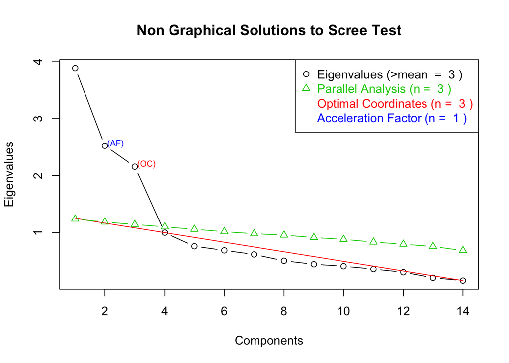

```r
###  Scree plot to estimate number of factors
ev <- eigen(cor(myData)) # get dataset eigenvalues
#ev <- eigen(polychoric(myData))
ap <- parallel(subject=nrow(myData),var=ncol(myData),rep=100,cent=.05) #get eigenvalues of random uncorrelated standardized normal variables.
nS <- nScree(x=ev$values, aparallel=ap$eigen$qevpea)
plotnScree(nS)
```

Note: Analysis based on Pearson correlations assumes continuous attributes that are normally distributed.  
Big5 is ordinal data estimating a continuous latent trait (polychoric correlation) and mathsData items are dichotomous (tetrachoric correlation).  
The function fa.parrallel generates **scree plots** based a range of types of correlation. The method can give the number of factors based on Factor Analysis (measurement of a latent variable) and the number of components based on Principal Component Analysis (linear combinations of variables). (This link gives a nice explanation of the difference between EFA and PCA: https://www.theanalysisfactor.com/the-fundamental-difference-between-principal-component-analysis-and-factor-analysis/ )

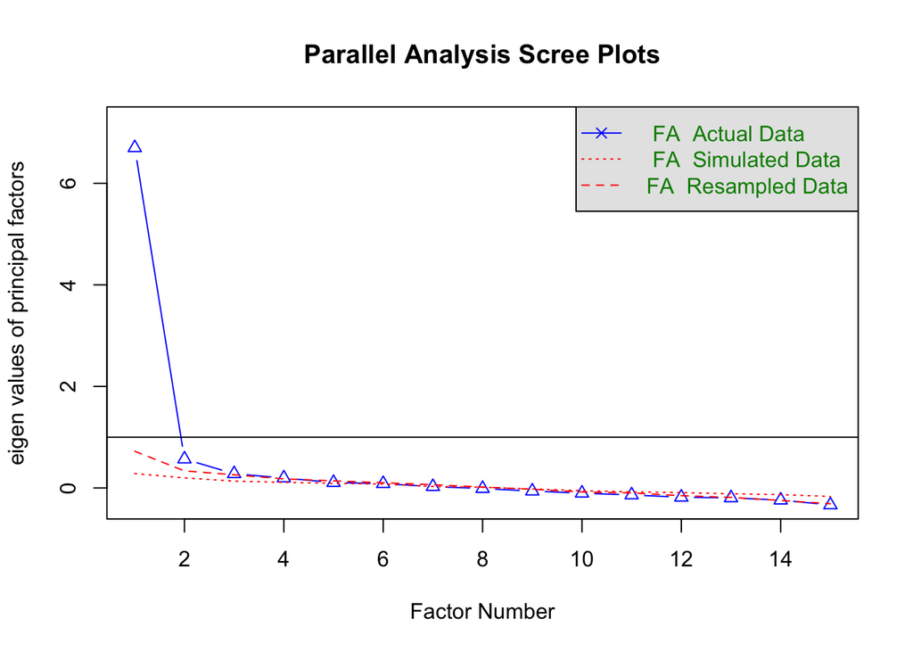

```
## Parallel analysis suggests that the number of factors =  6  and the number of components =  NA
```

```r
#fa.parallel(Big5Data,cor="poly", fm="ml", n.iter=10, fa="fa") #parameters: n.iter: number of simulations (default =10); fm: factor method, ml is maximum likelihood factor analysis; fa: choose between EFA and PCA, default is both. sim=FALSE would exclude simulated data.

fa.parallel(mathsData,cor="tet",fm="ml", n.iter=3, fa="fa")
```

```r
#EFA using tetra- / poly- choric correlation
#fa(r = myData, nfactors = 3, n.iter = 2, cor = "poly")
```

As an example of a fit that does not reject the null hypothesis, the code below does an EFA for the openness items as two factors.

```r
myData <- Big5Data

myData <- myData %>% select(starts_with("O"))   #Select conscientiouess and agreeableness
fit <- factanal(myData, 2, rotation="varimax")
print(fit, digits=2, cutoff=.3)
```

```
##
## Call:
## factanal(x = myData, factors = 2, rotation = "varimax")
##
## Uniquenesses:
##   O1   O2   O3   O4   O5
## 0.19 0.65 0.48 0.43 0.61
##
## Loadings:
##    Factor1 Factor2
## O1 0.89
## O2 0.50    0.32
## O3         0.69
## O4         0.74
## O5 0.47    0.41
##
##                Factor1 Factor2
## SS loadings       1.35    1.29
## Proportion Var    0.27    0.26
## Cumulative Var    0.27    0.53
##
## Test of the hypothesis that 2 factors are sufficient.
## The chi square statistic is 2.84 on 1 degree of freedom.
## The p-value is 0.0921
```

```r
#restore myData to all three factors again

myData <- Big5Data
```

##### Exercise:

Does EFA analysis reject a hypothesis that the dataset contains 5 factors?  
Do you think this is a reasonable analysis, or is there another explanation?

##### Exploring factors in the Maths dataset:

The fa functions in package ‘psych’ provides more prarameters for factor analysis. The Maths dataset has dichotomous variables, so the following uses tetrochloric correlation:

```r
myData<-mathsData
summary(fa(myData,1,cor="tet"))
```

```
##
##
## Factor analysis with Call: fa(r = myData, nfactors = 1, cor = "tet")
##
## Test of the hypothesis that 1 factor is sufficient.
## The degrees of freedom for the model is 90  and the objective function was  1.12
## The number of observations was  876  with Chi Square =  969.57  with prob <  1.7e-147
##
## The root mean square of the residuals (RMSA) is  0.06
## The df corrected root mean square of the residuals is  0.06
##
## Tucker Lewis Index of factoring reliability =  0.848
## RMSEA index =  0.106  and the 10 % confidence intervals are  0.1 0.112
## BIC =  359.79
```

##### Optional exercise:

Use the appropriate scree plot to visually explore the number of factors in the Maths dataset.

#### 3a.2 Confirmatory factor analysis (used to test an underlying theory)

```r
myData <- Big5Data  #could also use Big5DataR

#Define the theoretcial model to be assessed. IN this case: three distinct constructs
Big5.CFA.model <- 'open  =~ O1 + O2 + O3 + O4 + O5
               conn =~ C1 + C2 + C3 + C4
               agree   =~ A1 + A2 + A3 + A4 + A5'

#Test how well the data fits this model
fit <- cfa(Big5.CFA.model, data=myData)
summary(fit, fit.measures=TRUE)
```

```
## lavaan (0.5-23.1097) converged normally after  41 iterations
##
##   Number of observations                           491
##
##   Estimator                                         ML
##   Minimum Function Test Statistic              247.388
##   Degrees of freedom                                74
##   P-value (Chi-square)                           0.000
##
## Model test baseline model:
##
##   Minimum Function Test Statistic             3011.174
##   Degrees of freedom                                91
##   P-value                                        0.000
##
## User model versus baseline model:
##
##   Comparative Fit Index (CFI)                    0.941
##   Tucker-Lewis Index (TLI)                       0.927
##
## Loglikelihood and Information Criteria:
##
##   Loglikelihood user model (H0)              -9865.404
##   Loglikelihood unrestricted model (H1)      -9741.710
##
##   Number of free parameters                         31
##   Akaike (AIC)                               19792.807
##   Bayesian (BIC)                             19922.897
##   Sample-size adjusted Bayesian (BIC)        19824.504
##
## Root Mean Square Error of Approximation:
##
##   RMSEA                                          0.069
##   90 Percent Confidence Interval          0.060  0.079
##   P-value RMSEA <= 0.05                          0.001
##
## Standardized Root Mean Square Residual:
##
##   SRMR                                           0.048
##
```

[output cut: 37 more lines]

```
##    .O3                0.758    0.062   12.227    0.000
##    .O4                0.997    0.079   12.564    0.000
##    .O5                0.750    0.064   11.677    0.000
##    .C1                0.630    0.055   11.452    0.000
##    .C2                1.062    0.076   14.002    0.000
##    .C3                0.384    0.044    8.744    0.000
##    .C4                0.619    0.053   11.771    0.000
##    .A1                0.656    0.048   13.801    0.000
##    .A2                0.336    0.038    8.899    0.000
##    .A3                0.547    0.041   13.302    0.000
##    .A4                0.375    0.031   12.004    0.000
##    .A5                0.553    0.039   14.133    0.000
##     open              0.853    0.141    6.068    0.000
##     conn              2.375    0.191   12.418    0.000
##     agree             0.349    0.054    6.517    0.000
```

## Section 3b: Reliability

```r
#Cronbach Alpha
#Reverse scored items need to be 'fixed', so this section will use Big5DataR
myData <- Big5DataR

#Openness
dataOpen<-select(myData,starts_with("O"))
alphaO<-psych::alpha(dataOpen)   #psych:: denotes package name; psychometric:: also has an aplpha function that returns just a single figure.
print(alphaO$total, digits=2, cutoff=.3)
```

```
##  raw_alpha std.alpha G6(smc) average_r S/N   ase mean   sd
##       0.74      0.75    0.73      0.38   3 0.018  5.9 0.92
```

```r
#Conscientousnesss
dataConn<-select(myData,starts_with("C"))
alphaC<-psych::alpha(dataConn)
print(alphaC$total, digits=2, cutoff=.3)
```

```
##  raw_alpha std.alpha G6(smc) average_r S/N    ase mean  sd
##       0.93      0.93    0.91      0.76  12 0.0055  3.8 1.5
```

```r
#Agreeableness
dataConn<-select(myData,starts_with("A"))
alphaA<-psych::alpha(dataConn)
print(alphaA$total, digits=2, cutoff=.3)
```

```
##  raw_alpha std.alpha G6(smc) average_r S/N   ase mean  sd
##       0.79      0.79    0.77      0.43 3.8 0.015  3.9 0.7
```

Exercise:

What is the realibility of the Maths dataset as estimated by Cronbach alpha?

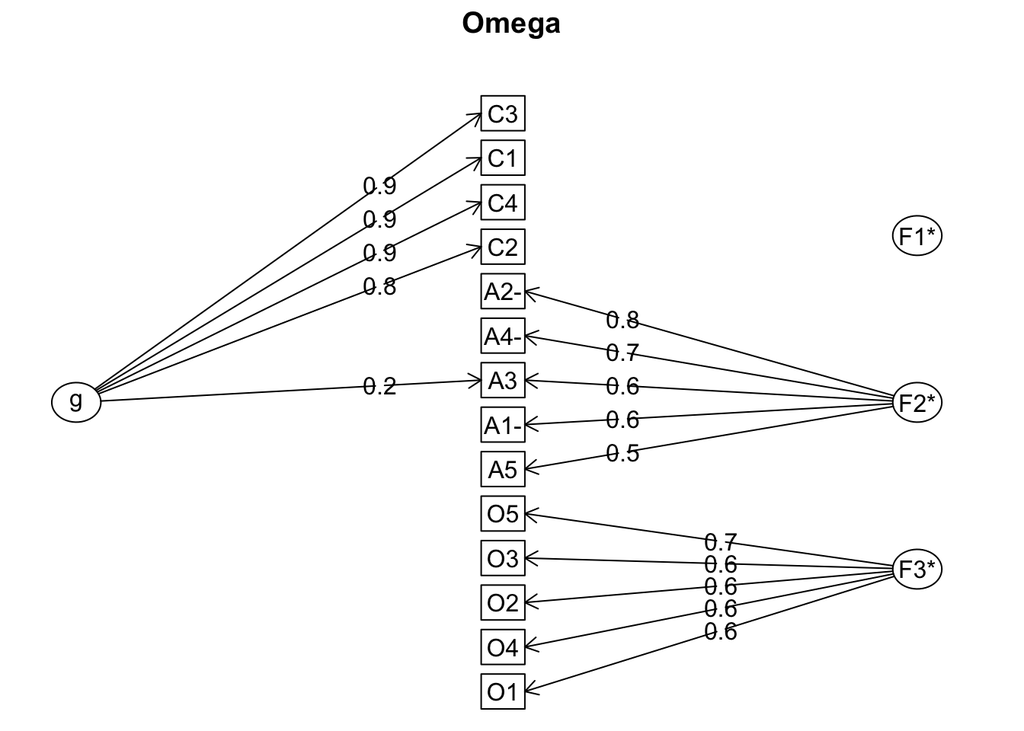

```
## Omega
## Call: omega(m = myData, nfactors = 3)
## Alpha:                 0.78
## G.6:                   0.85
## Omega Hierarchical:    0.48
## Omega H asymptotic:    0.55
## Omega Total            0.86
##
## Schmid Leiman Factor loadings greater than  0.2
##         g   F1*   F2*   F3*   h2   u2   p2
## O1                     0.58 0.34 0.66 0.02
## O2                     0.59 0.36 0.64 0.02
## O3                     0.61 0.39 0.61 0.06
## O4                     0.59 0.37 0.63 0.06
## O5                     0.65 0.44 0.56 0.03
## C1   0.89                   0.80 0.20 1.00
## C2   0.78                   0.62 0.38 0.99
## C3   0.93                   0.87 0.13 1.00
## C4   0.87                   0.76 0.24 1.00
## A1-              0.57       0.33 0.67 0.03
## A2-              0.79       0.66 0.34 0.04
## A3   0.24        0.62       0.44 0.56 0.13
## A4-              0.67       0.48 0.52 0.06
## A5               0.54       0.33 0.67 0.09
##
## With eigenvalues of:
##    g  F1*  F2*  F3*
## 3.26 0.01 2.08 1.84
##
## general/max  1.57   max/min =   218.1
## mean percent general =  0.32    with sd =  0.44 and cv of  1.37
## Explained Common Variance of the general factor =  0.45
##
## The degrees of freedom are 52  and the fit is  0.45
## The number of observations was  491  with Chi Square =  216.44  with prob <  6e-22
## The root mean square of the residuals is  0.04
## The df corrected root mean square of the residuals is  0.05
## RMSEA index =  0.081  and the 10 % confidence intervals are  0.069 0.092
## BIC =  -105.77
##
## Compare this with the adequacy of just a general factor and no group factors
## The degrees of freedom for just the general factor are 77  and the fit is  2.68
## The number of observations was  491  with Chi Square =  1295.67  with prob <  1.5e-220
## The root mean square of the residuals is  0.19
## The df corrected root mean square of the residuals is  0.2
##
## RMSEA index =  0.181  and the 10 % confidence intervals are  0.171 0.188
## BIC =  818.54
##
## Measures of factor score adequacy
##                                                  g   F1*  F2*  F3*
## Correlation of scores with factors            0.97  0.06 0.90 0.87
## Multiple R square of scores with factors      0.94  0.00 0.81 0.75
## Minimum correlation of factor score estimates 0.87 -0.99 0.62 0.50
##
##  Total, General and Subset omega for each subset
##                                                  g  F1*  F2*  F3*
## Omega total for total scores and subscales    0.86 0.93 0.80 0.75
## Omega general for total scores and subscales  0.48 0.92 0.05 0.03
## Omega group for total scores and subscales    0.38 0.00 0.74 0.73
```

```r
#Omega - gives alpha, omega & G.6, for an overall factor (g) and individual factors (F1...)
omega(myData,3)   # 3 factors; principal axis factor analysis (default)
```

##### Exercise:

In the maths datset, does Omega differ from Alpha for a 1-factor model?

## 3c: Error measurement

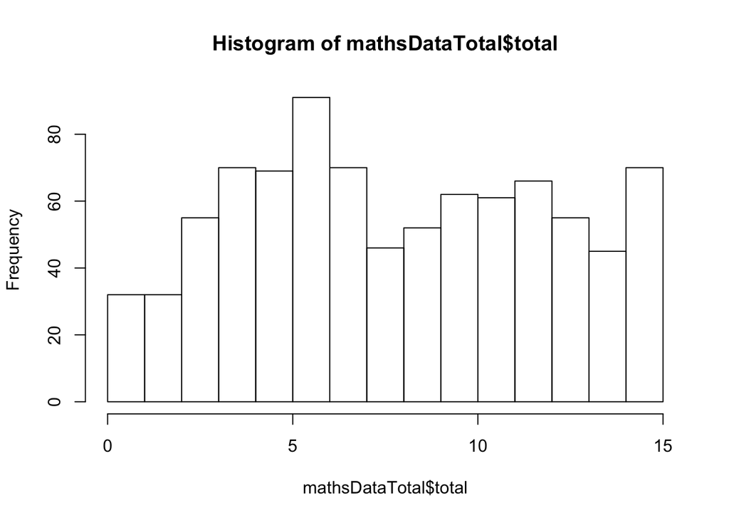

```r
#1. Add a final total for each student
mathsDataTotal<-mutate(mathsData, total=rowSums(mathsData)) #creates a new column, total, which is the sum of the other columns
hist(mathsDataTotal$total)
```

```r
myData<-mathsDataTotal

#N, mean, standard devation:
n<-nrow(myData)  #number of rows
m<-mean(myData$total)
s<-sd(myData$total)
rxx<-0.86 #from Omega estimate above

#Standard error of the mean: how close is the class average to a population average
se.mean<-s/sqrt(n)
cat("mean: ", m, "; Standard error of the mean: ", round(se.mean,2)) #cat = concatenate
```

```
## mean:  8.25 ; Standard error of the mean:  0.14
```

##### Optional exercise:

Optional Excercise: What is the standard error for Conscientiousness?

## Section 4: Classical Test Theory

```r
#1. Simple item difficult
myData<-mathsData
itemDifficulty<-colMeans(myData)
print(itemDifficulty, digits=2)
```

```
##   I1   I2   I3   I4   I5   I6   I7   I8   I9  I10  I11  I12  I13  I14  I15
## 0.48 0.45 0.81 0.47 0.59 0.40 0.42 0.45 0.50 0.61 0.84 0.46 0.47 0.68 0.63
```

```r
#2. Item discrimination (relationship with latent trait)
#Estimated as: (number correct in the top third - number correct in the bottom third ) / size of each group.
itemDiscrimination<-discrim(myData)
print(itemDiscrimination, digits=2)
```

```
##   I1   I2   I3   I4   I5   I6   I7   I8   I9  I10  I11  I12  I13  I14  I15
## 0.63 0.75 0.36 0.59 0.73 0.73 0.70 0.81 0.81 0.60 0.30 0.59 0.63 0.62 0.49
```

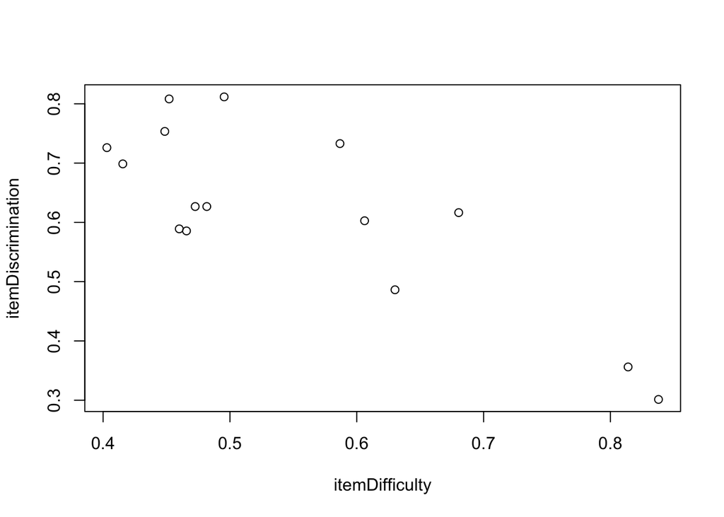

```r
#3. Does a particular difficulty range provide better discrimination?
plot(itemDiscrimination~itemDifficulty)
```

#### Section 4a: Measurement error again

```r
myData<-mathsDataTotal
#N, mean, standard devation:
n<-nrow(myData)  #number of rows
m<-mean(myData$total)
s<-sd(myData$total)
rxx<-0.86 #from Omega estimate above


###CI for observed and true scores
#select the total score for one person (e.g. the code below selects the person in row 1)
Person1<-mathsDataTotal[1,"total"]

#Confidence interval for one person's observed score, uses: (SE.Meas<-s*sqrt(1-rxx))
CI.Person1.obs<-CI.obs(Person1, s, rxx, level = 0.95) #95% confidence interval of observed score
print(CI.Person1.obs, digits=2)
```

```
##   SE.Meas LCL OBS UCL
## 1     1.5   9  12  15
```

```r
#confidence interval for the estimated true score, uses: (SE.Est<-s*sqrt((1-rxx)*rxx))
CI.Person1.true<-CI.tscore(Person1, m, s, rxx, level = 0.95) #95% confidence interval of observed score
print(CI.Person1.true, digits=2)
```

```
##   SE.Est LCL T.Score UCL
## 1    1.4 8.7      11  14
```

## Section 5: Item Response Theory

The following code generates 1PL and 2PL models of the Maths dataset.

#### Rasch Model (1PL)

```r
myData<-mathsData
my1PL<-tam.mml(myData)   # or my1PL<-tam.jml(myData)
my1PL.fit<-tam.fit(my1PL)
```

```r
#View ICC plots
op<-par()   #store default plot parameters (to reset later)
par(mfrow=c(5,3), mar=c(1,3,3,2))           #adjust mfrow for grid size: (rows,colums); mar=margins(b,l,t,r)
plot(my1PL)
par(op)   #reset to default plot parameters
```

[output not shown]

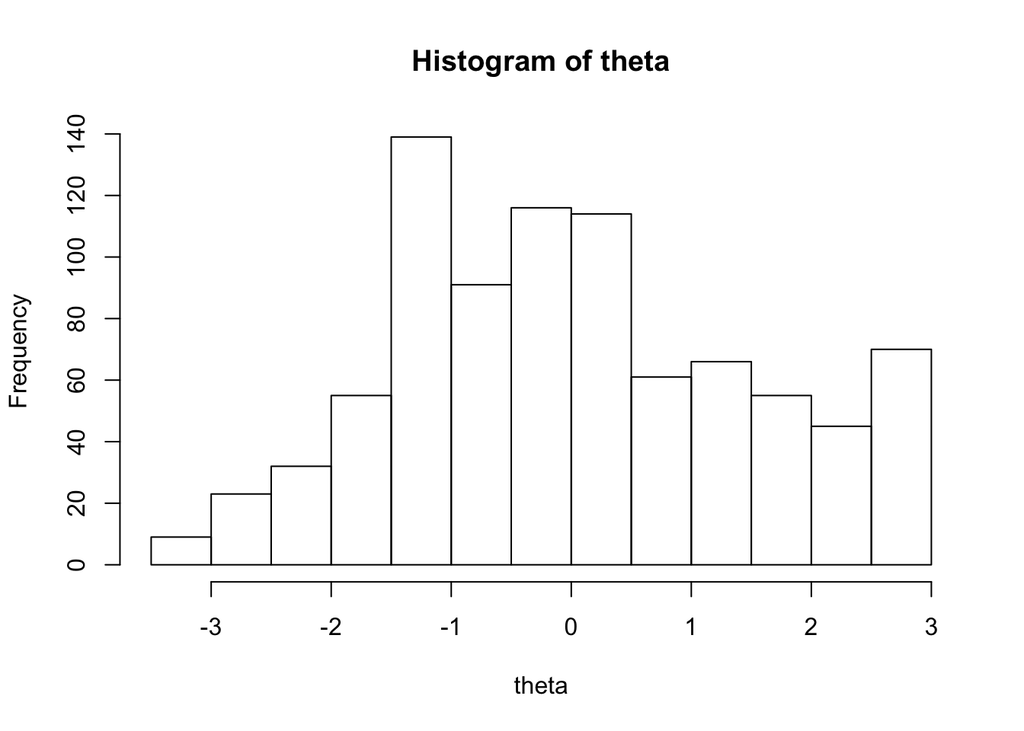

```r
#Student ability estimates
theta<-my1PL$person$EAP                  #For mml
#theta<-my1PL$WLE                        #For jml
hist(theta)
```

```r
#Item difficulty estimates
print(my1PL$xsi, digits=2)
```

```
##        xsi se.xsi
## I1   0.068  0.081
## I2   0.259  0.082
## I3  -2.055  0.098
## I4   0.160  0.081
## I5  -0.536  0.081
## I6   0.529  0.083
## I7   0.454  0.082
## I8   0.239  0.081
## I9  -0.011  0.081
## I10 -0.649  0.082
## I11 -2.268  0.103
## I12  0.193  0.081
## I13  0.120  0.081
## I14 -1.099  0.085
## I15 -0.791  0.083
```

```r
#residuals
summary(my1PL.fit)
```

```
##    parameter Outfit Outfit_t Outfit_p Infit Infit_t Infit_p
## 1         I1  1.039    0.550    0.583 1.043   1.171   0.242
## 2         I2  0.874   -1.797    0.072 0.925  -2.055   0.040
## 3         I3  1.173    0.999    0.318 1.039   0.720   0.471
## 4         I4  1.276    3.528    0.000 1.111   2.933   0.003
## 5         I5  0.817   -2.386    0.017 0.909  -2.597   0.009
## 6         I6  0.888   -1.505    0.132 0.908  -2.447   0.014
## 7         I7  0.934   -0.882    0.378 0.947  -1.394   0.163
## 8         I8  0.757   -3.650    0.000 0.839  -4.603   0.000
## 9         I9  0.726   -4.208    0.000 0.824  -5.178   0.000
## 10       I10  1.070    0.816    0.414 1.070   1.884   0.060
## 11       I11  1.364    1.746    0.081 1.075   1.226   0.220
## 12       I12  1.133    1.783    0.075 1.095   2.499   0.012
## 13       I13  1.029    0.410    0.682 1.042   1.130   0.259
## 14       I14  0.903   -0.940    0.347 0.963  -0.953   0.341
## 15       I15  1.318    3.197    0.001 1.207   5.246   0.000
```

### 2PL IRT model

```r
my2PL<-tam.mml.2pl(myData)
my2PL.fit<-tam.fit(my2PL)
```

```r
summary(my2PL.fit)
```

```
##    parameter Outfit Outfit_t Outfit_p Infit Infit_t Infit_p
## 1         I1  0.988   -0.173    0.863 1.007   0.209   0.834
## 2         I2  0.988   -0.093    0.926 1.003   0.077   0.939
## 3         I3  1.022    0.212    0.832 0.992  -0.127   0.899
## 4         I4  1.018    0.406    0.684 0.992  -0.262   0.793
## 5         I5  1.000    0.001    0.999 1.004   0.098   0.922
## 6         I6  1.065    0.513    0.608 0.988  -0.260   0.795
## 7         I7  1.038    0.354    0.724 0.991  -0.203   0.839
## 8         I8  0.974   -0.057    0.955 1.003   0.076   0.939
## 9         I9  0.916   -0.204    0.839 1.007   0.147   0.883
## 10       I10  0.976   -0.365    0.715 1.004   0.137   0.891
## 11       I11  1.019    0.195    0.845 0.993  -0.102   0.918
## 12       I12  0.998   -0.029    0.977 0.995  -0.152   0.879
## 13       I13  0.986   -0.240    0.810 1.003   0.095   0.925
## 14       I14  0.999    0.025    0.980 1.007   0.172   0.863
## 15       I15  0.984   -0.390    0.696 1.006   0.237   0.813
```

```r
#Compare ICC for 1PL and 2PL

op<-par()   #store default plot parameters (to reset later)
par(mfrow=c(5,3), mar=c(1,3,3,2))           #adjust mfrow for grid size: (rows,colums); mar=margins(b,l,t,r)
plot(my2PL)
par(op)   #reset to default plot parameters
```

[output not shown]

##### Other useful commands

```r
rm(list=ls())   #clear the environment
search()      #shows the order in which packages are searched for a function.
```